# Model Selection – Part 2 (Notes)

Stat 253

Author

Your Name

## Notes: Variable Selection

**GOAL**

Let’s consider three existing variable selection algorithms.

Heads up: these algorithms are important to building intuition for the questions and challenges in model selection, BUT have major drawbacks.

## EXAMPLE 1: Best Subset Selection Algorithm

- Build *all* $2^p$ possible models that use any combination of the available predictors $(x_1, x_2,..., x_p)$.
- Identify the best model with respect to some chosen metric (eg: CV MAE) and context.

Suppose we used this algorithm for our `height` model with 12 possible predictors. What’s the main drawback?

> ANSWER

## EXAMPLE 2: Backward Stepwise Selection Algorithm

- Build a model with *all* $p$ possible predictors, $(x_1, x_2,..., x_p)$.
- Repeat the following until only 1 predictor remains in the model:
  - Remove the 1 predictor with the biggest p-value.
  - Build a model with the remaining predictors.
- You now have $p$ competing models: one with all $p$ predictors, one with $p-1$ predictors, …, and one with 1 predictor. Identify the “best” model with respect to some metric (eg: CV MAE) and context.

Let’s try out the first few steps!

```r
# Load packages and data
library(tidyverse)
library(tidymodels)
humans <- read.csv("https://kegrinde.github.io/stat253_coursenotes/data/bodyfat1.csv")
```

```r
# STEP 1: model specifications
lm_spec <- linear_reg() %>%
  set_mode("regression") %>%
  set_engine("lm")

# STEP 2: model estimate (using all 12 predictors to start)
# Pick apart this code and make it easier to identify the least "significant" predictor!!!
lm_spec %>%
  fit(height ~ age + weight + neck + chest + abdomen + hip + thigh + knee + ankle + biceps + forearm + wrist,
      data = humans) %>%
  tidy() %>%
  filter(term != "(Intercept)") %>%
  mutate(p.value = round(p.value, 4))
## # A tibble: 12 × 5
##    term    estimate std.error statistic p.value
##    <chr>      <dbl>     <dbl>     <dbl>   <dbl>
##  1 age      -0.112      0.132    -0.847  0.405
##  2 weight    0.379      0.213     1.78   0.0864
##  3 neck      0.139      1.17      0.119  0.906
##  4 chest    -0.459      0.473    -0.971  0.340
##  5 abdomen   0.283      0.354     0.798  0.432
##  6 hip      -0.921      0.510    -1.81   0.0822
##  7 thigh    -1.24       0.646    -1.92   0.066
##  8 knee      0.151      0.941     0.160  0.874
##  9 ankle    -0.888      1.28     -0.693  0.494
## 10 biceps   -0.0808     0.746    -0.108  0.915
## 11 forearm   2.25       1.80      1.25   0.223
## 12 wrist     0.836      2.32      0.361  0.721
```

```r
# 11 predictors (tweak the code)
lm_spec %>%
  fit(height ~ age + weight + neck + chest + abdomen + hip + thigh + knee + ankle + biceps + forearm + wrist,
      data = humans) %>%
  tidy() %>%
  filter(term != "(Intercept)") %>%
  mutate(p.value = round(p.value, 4))
## # A tibble: 12 × 5
##    term    estimate std.error statistic p.value
##    <chr>      <dbl>     <dbl>     <dbl>   <dbl>
##  1 age      -0.112      0.132    -0.847  0.405
##  2 weight    0.379      0.213     1.78   0.0864
##  3 neck      0.139      1.17      0.119  0.906
##  4 chest    -0.459      0.473    -0.971  0.340
##  5 abdomen   0.283      0.354     0.798  0.432
##  6 hip      -0.921      0.510    -1.81   0.0822
##  7 thigh    -1.24       0.646    -1.92   0.066
##  8 knee      0.151      0.941     0.160  0.874
##  9 ankle    -0.888      1.28     -0.693  0.494
## 10 biceps   -0.0808     0.746    -0.108  0.915
## 11 forearm   2.25       1.80      1.25   0.223
## 12 wrist     0.836      2.32      0.361  0.721
```

```r
# 10 predictors (tweak the code)
lm_spec %>%
  fit(height ~ age + weight + neck + chest + abdomen + hip + thigh + knee + ankle + biceps + forearm + wrist,
      data = humans) %>%
  tidy() %>%
  filter(term != "(Intercept)") %>%
  mutate(p.value = round(p.value, 4))
## # A tibble: 12 × 5
##    term    estimate std.error statistic p.value
##    <chr>      <dbl>     <dbl>     <dbl>   <dbl>
##  1 age      -0.112      0.132    -0.847  0.405
##  2 weight    0.379      0.213     1.78   0.0864
##  3 neck      0.139      1.17      0.119  0.906
##  4 chest    -0.459      0.473    -0.971  0.340
##  5 abdomen   0.283      0.354     0.798  0.432
##  6 hip      -0.921      0.510    -1.81   0.0822
##  7 thigh    -1.24       0.646    -1.92   0.066
##  8 knee      0.151      0.941     0.160  0.874
##  9 ankle    -0.888      1.28     -0.693  0.494
## 10 biceps   -0.0808     0.746    -0.108  0.915
## 11 forearm   2.25       1.80      1.25   0.223
## 12 wrist     0.836      2.32      0.361  0.721
```

## EXAMPLE 3: Backward Stepwise Selection Step-by-Step Results

Below is the complete model sequence along with 10-fold CV MAE for each model (using `set.seed(253)`).

| pred | CV MAE | predictor list |
| --- | --- | --- |
| 12 | 5.728 | weight, hip, forearm, thigh, chest, abdomen, age, ankle, wrist, knee, neck, biceps |
| 11 | 5.523 | weight, hip, forearm, thigh, chest, abdomen, age, ankle, wrist, knee, neck |
| 10 | 5.413 | weight, hip, forearm, thigh, chest, abdomen, age, ankle, wrist, knee |
| 9 | 5.368 | weight, hip, forearm, thigh, chest, abdomen, age, ankle, wrist |
| 8 | 5.047 | weight, hip, forearm, thigh, chest, abdomen, age, ankle |
| 7 | 5.013 | weight, hip, forearm, thigh, chest, abdomen, age |
| 6 | 4.684 | weight, hip, forearm, thigh, chest, abdomen |
| 5 | 4.460 | weight, hip, forearm, thigh, chest |
| 4 | 4.386 | weight, hip, forearm, thigh |
| 3 | 4.091 | weight, hip, forearm |
| 2 | 3.733 | weight, hip |
| 1 | 3.658 | weight |

1. REVIEW: Interpret the CV MAE for the model of `height` by `weight` alone.

> ANSWER
2. Is this algorithm more or less **computationally expensive** than the best subset algorithm?

> ANSWER
3. The predictors `neck` and `wrist`, in that order, are the most strongly correlated with `height`. Where do these appear in the backward sequence and what does this mean?

```r
cor(humans)[,'height'] %>%
  sort()
##       thigh         hip         age     abdomen        knee       chest
## -0.11301249 -0.10648937 -0.05853538 -0.02173587  0.02345904  0.05838830
##      biceps       ankle      weight     forearm       wrist        neck
##  0.07441696  0.07920867  0.11228791  0.16968040  0.28967468  0.29147610
##      height
##  1.00000000
```

> ANSWER
4. We deleted predictors one at a time. Why is this better than deleting a collection of multiple predictors at the same time (eg: kicking out all predictors with p-value > 0.1)?

> ANSWER

## EXAMPLE 4: Backward Stepwise Selection Final Model

We have to pick just **1** of the 12 models as our final model. That is, we have to pick a value for our **tuning parameter**, the number of predictors. It helps to plot the CV MAE for each model in the sequence.

**Here’s what we saw above:**

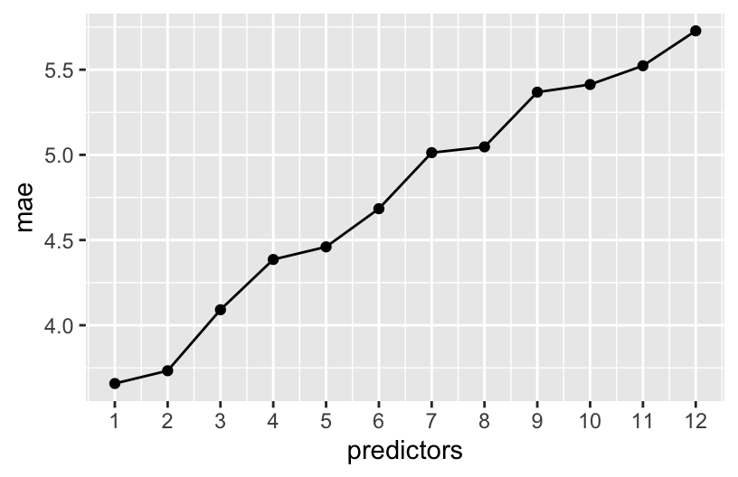

```r
data.frame(
    predictors = c(12:1),
    mae = c(5.728, 5.523, 5.413, 5.368, 5.047, 5.013, 4.684, 4.460, 4.386, 4.091, 3.733, 3.658)) %>%
  ggplot(aes(x = predictors, y = mae)) +
    geom_point() +
    geom_line() +
    scale_x_continuous(breaks = c(1:12))
```

**Here’s another example from a different subset of these data:**

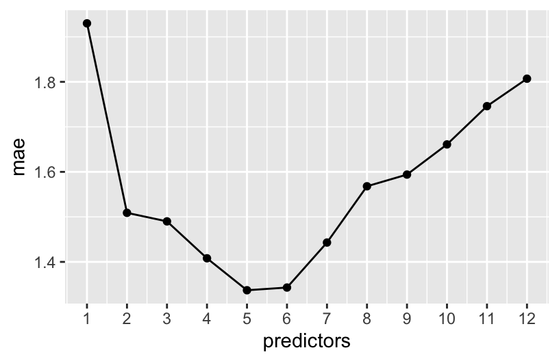

1. In the odd [“Goldilocks” fairy tale](https://www.youtube.com/watch?v=qOJ_A5tgBKM), a kid comes upon a bear den – the first bear’s bed is too hard, the second bear’s is too soft, and the third bear’s is just right. Our plot illustrates a **goldilocks problem** in tuning the number of predictors in our backward stepwise model. Explain.

> ANSWER
2. Which model do you pick?!?

> ANSWER

## EXAMPLE 5: machine learning vs human learning

When *tuning* or finalizing a model building algorithm, we (humans!) have our own choices to make. For one, we need to decide what we prefer:

- a model with the lowest prediction errors; or
- a more **parsimonious** model: one with slightly *higher prediction errors* but *fewer predictors*

In deciding, here are some human considerations:

- **goal:** How will the model be used? Should it be easy for humans to interpret and apply?
- **cost:** How many resources (time, money, computer memory, etc) do the model and data needed require?
- **impact:** What are the consequences of a bad prediction?

For each scenario below, which model would you pick: (1) the model with the lowest prediction errors; or (2) a parsimonious model with slightly worse predictions?

1. Google asks us to re-build their search algorithm.

> ANSWER
2. A small non-profit hires us to help them build a predictive model of the donation dollars they’ll receive throughout the year.

> ANSWER

## EXAMPLE 6: Forward Stepwise Selection Algorithm

- How do you think this works?

> ANSWER
- Is it more or less computationally expensive than backward stepwise?

> ANSWER

## WARNING

Variable selection algorithms are a nice, intuitive place to start our discussion of model selection techniques.

**BUT we will not use them.**

They are frowned upon in the broader ML community, so much so that **tidymodels** doesn’t even implement them!

Why?

- Best subset selection is **computationally expensive**.
- Backward stepwise selection:
  - is **greedy** – it makes *locally* optimal decisions, thus often misses the *globally* optimal model
  - overestimates the significance of remaining predictors, thus shouldn’t be used for inference
- Forward stepwise selection:
  - is computationally expensive
  - can produce odd combinations of predictors (eg: a new predictor may render previously included predictors non-significant).

# Exercises

The video for today introduced the concepts of **recipes** and **workflows** in the **tidymodels** framework. These concepts will become important to our new modeling algorithms. Though they aren’t *necessary* to linear regression models, let’s explore them in this familiar setting.

Run through the following discussion and code one step at a time. Take note of the general process, concepts, and questions you have.

**STEP 1: model specification**

This specifies the *structure* or general modeling algorithm we plan to use. It does *not* specify anything about the variables of interest or our data.

```r
lm_spec <- linear_reg() %>%
  set_mode("regression") %>%
  set_engine("lm")

# Check it out
lm_spec
## Linear Regression Model Specification (regression)
##
## Computational engine: lm
```

**STEP 2: recipe specification**

Just as a cooking recipe specifies the *ingredients* and *how to prepare them*, a tidymodels recipe specifies:

- the *variables* in our relationship of interest (the ingredients)
- how to *pre-process* or wrangle these variables (how to prepare the ingredients)
- the *data* we’ll use to explore these variables (where to find the ingredients)

It does *not* specify anything about the model structure we’ll use to explore this relationship.

```r
# A simple recipe with NO pre-processing
data_recipe <- recipe(height ~ wrist + ankle, data = humans)

# Check it out
data_recipe
```

**STEP 3: workflow creation (model + recipe)**

This specifies the general *workflow* of our modeling process, including our *model structure* and our *variable recipe*.

```r
model_workflow <- workflow() %>%
  add_recipe(data_recipe) %>%
  add_model(lm_spec)

# Check it out
model_workflow
## ══ Workflow ════════════════════════════════════════════════════════════════════
## Preprocessor: Recipe
## Model: linear_reg()
##
## ── Preprocessor ────────────────────────────────────────────────────────────────
## 0 Recipe Steps
##
## ── Model ───────────────────────────────────────────────────────────────────────
## Linear Regression Model Specification (regression)
##
## Computational engine: lm
```

**STEP 4: Model estimation**

This step *estimates* or *fits* our model of interest using our entire sample data.

The model (`lm_spec`) and variable details (here just `height ~ wrist + ankle`) are specified in the workflow, so we do not need to give that information again!

```r
my_model <- model_workflow %>%
  fit(data = humans)
```

**STEPS 5: Model evaluation**

To get in-sample metrics, use `my_model` like normal.

To get CV metrics, pass the workflow to `fit_resamples` along with information about how to randomly create folds.

```r
set.seed(253)
my_model_cv <- model_workflow %>%
  fit_resamples(resamples = vfold_cv(humans, v = 10))
```